# Part I - Kitty of Angels Adoption vs. Donation Campaigns

## Preliminary Wrangling

```python
# import all packages and set plots to be embedded inline
import numpy as np
import pandas as pd
import matplotlib.pyplot as plt
import seaborn as sns
```

```python
# Loading the 'outcomes' dataset
koa_adoptions = pd.read_csv('outcomes_cleaned.csv')

# Showing the head of the dataset
koa_adoptions.head()
```

|  | Outcome Date | Animal ID | Name | Species | Primary Breed | Sex | Outcome Description |
| --- | --- | --- | --- | --- | --- | --- | --- |
| 0 | 2023-08-26 | RTLA-A-1257 | Cricket | Cat | Domestic Shorthair | Female | Adoption - Mobile Adoption |
| 1 | 2023-08-25 | RTLA-A-1125 | Indie | Cat | Domestic Shorthair | Female | Adoption - Mobile Adoption |
| 2 | 2023-08-25 | RTLA-A-1124 | Elly | Cat | Domestic Shorthair | Female | Adoption - Mobile Adoption |
| 3 | 2023-08-25 | RTLA-A-1280 | Twee | Cat | Domestic Shorthair | Female | Adoption - Mobile Adoption |
| 4 | 2023-08-21 | RTLA-A-1241 | Jen | Cat | Domestic Shorthair | Female | Adoption - Mobile Adoption |

```python
# Loading the 'donations_taken_2023' dataset
donations_taken_2023 = pd.read_csv('donations_taken_2023.csv')

# Showing the head of the dataset
donations_taken_2023.head(0)
```

|  | Transaction ID | Transaction Date | Department | Donation Amount | By | Cash Drawer | Person ID # | First Name | Last Name | Email Address | Address | Home Phone | Cell Phone | Work Phone | Visit Type | Payment Type | Donation Memo |
| --- | --- | --- | --- | --- | --- | --- | --- | --- | --- | --- | --- | --- | --- | --- | --- | --- | --- |

```python
# Loading the 'google_ads_adoption' dataset
google_ads_adoption = pd.read_csv('google_ads_adoption.csv')

# Showing the head of the dataset
google_ads_adoption.head()
```

|  | Date | Clicks | Impressions | CTR | Cost |
| --- | --- | --- | --- | --- | --- |
| 0 | Sun, Mar 26, 2023 | 0 | 1 | 0.00% | $0.00 |
| 1 | Mon, Mar 27, 2023 | 0 | 0 | 0.00% | $0.00 |
| 2 | Tue, Mar 28, 2023 | 4 | 44 | 9.09% | $58.20 |
| 3 | Wed, Mar 29, 2023 | 10 | 105 | 9.52% | $169.09 |
| 4 | Thu, Mar 30, 2023 | 8 | 144 | 5.56% | $134.98 |

```python
# Loading the 'google_ads_donation' dataset
google_ads_donation = pd.read_csv('google_ads_donation.csv')

# Showing the head of the dataset
google_ads_donation.head()
```

|  | Date | Clicks | Impressions | CTR | Cost |
| --- | --- | --- | --- | --- | --- |
| 0 | Sun, Mar 26, 2023 | 1 | 4 | 25.00% | $12.30 |
| 1 | Mon, Mar 27, 2023 | 0 | 2 | 0.00% | $0.00 |
| 2 | Tue, Mar 28, 2023 | 2 | 14 | 14.29% | $29.97 |
| 3 | Wed, Mar 29, 2023 | 0 | 2 | 0.00% | $0.00 |
| 4 | Thu, Mar 30, 2023 | 4 | 17 | 23.53% | $57.59 |

### How are your datasets structured?

**koa_adoptions**:

```python
# Getting the number of rows and columns of the dataset
koa_adoptions.shape
```

```
(1299, 7)
```

```python
# Getting information about the dataset
koa_adoptions.info()

# There are 10 null values in the 'Primary Breed' column
```

```
<class 'pandas.core.frame.DataFrame'>
RangeIndex: 1299 entries, 0 to 1298
Data columns (total 7 columns):
 #   Column               Non-Null Count  Dtype
---  ------               --------------  -----
 0   Outcome Date         1299 non-null   object
 1   Animal ID            1299 non-null   object
 2   Name                 1299 non-null   object
 3   Species              1299 non-null   object
 4   Primary Breed        1289 non-null   object
 5   Sex                  1299 non-null   object
 6   Outcome Description  1299 non-null   object
dtypes: object(7)
memory usage: 71.2+ KB
```

```python
# Checking for duplicates
koa_adoptions.duplicated().sum()

# There are no duplicates
```

```
0
```

```python
# Checking the data types of the columns
koa_adoptions.dtypes
```

```
Outcome Date           object
Animal ID              object
Name                   object
Species                object
Primary Breed          object
Sex                    object
Outcome Description    object
dtype: object
```

**donations_taken_2023**:

```python
# Getting the number of rows and columns of the dataset
donations_taken_2023.shape
```

```
(69, 17)
```

```python
# Getting information about the dataset
donations_taken_2023.info()

# There are no null values
```

```
<class 'pandas.core.frame.DataFrame'>
RangeIndex: 69 entries, 0 to 68
Data columns (total 17 columns):
 #   Column            Non-Null Count  Dtype
---  ------            --------------  -----
 0   Transaction ID    69 non-null     object
 1   Transaction Date  69 non-null     object
 2   Department        69 non-null     object
 3   Donation Amount   69 non-null     object
 4   By                69 non-null     object
 5   Cash Drawer       69 non-null     object
 6   Person ID #       69 non-null     object
 7   First Name        69 non-null     object
 8   Last Name         69 non-null     object
 9   Email Address     69 non-null     object
 10  Address           69 non-null     object
 11  Home Phone        69 non-null     object
 12  Cell Phone        69 non-null     object
 13  Work Phone        69 non-null     object
 14  Visit Type        69 non-null     object
 15  Payment Type      69 non-null     object
 16  Donation Memo     69 non-null     object
dtypes: object(17)
memory usage: 9.3+ KB
```

```python
# Checking for duplicates
donations_taken_2023.duplicated().sum()

# There are no duplicates
```

```
0
```

```python
# Checking the data types of the columns
donations_taken_2023.dtypes
```

```
Transaction ID      object
Transaction Date    object
Department          object
Donation Amount     object
By                  object
Cash Drawer         object
Person ID #         object
First Name          object
Last Name           object
Email Address       object
Address             object
Home Phone          object
Cell Phone          object
Work Phone          object
Visit Type          object
Payment Type        object
Donation Memo       object
dtype: object
```

**google_ads_adoption**:

```python
# Getting the number of rows and columns of the dataset
google_ads_adoption.shape
```

```
(93, 5)
```

```python
# Getting information about the dataset
google_ads_adoption.info()

# There are no null values
```

```
<class 'pandas.core.frame.DataFrame'>
RangeIndex: 93 entries, 0 to 92
Data columns (total 5 columns):
 #   Column       Non-Null Count  Dtype
---  ------       --------------  -----
 0   Date         93 non-null     object
 1   Clicks       93 non-null     int64
 2   Impressions  93 non-null     int64
 3   CTR          93 non-null     object
 4   Cost         93 non-null     object
dtypes: int64(2), object(3)
memory usage: 3.8+ KB
```

```python
# Checking for duplicates
google_ads_adoption.duplicated().sum()

# There are no duplicates
```

```
0
```

```python
# Checking the data types of the columns
google_ads_adoption.dtypes
```

```
Date           object
Clicks          int64
Impressions     int64
CTR            object
Cost           object
dtype: object
```

**google_ads_donation**:

```python
# Getting the number of rows and columns of the dataset
google_ads_donation.shape
```

```
(93, 5)
```

```python
# Getting information about the dataset
google_ads_donation.info()

# There are no null values
```

```
<class 'pandas.core.frame.DataFrame'>
RangeIndex: 93 entries, 0 to 92
Data columns (total 5 columns):
 #   Column       Non-Null Count  Dtype
---  ------       --------------  -----
 0   Date         93 non-null     object
 1   Clicks       93 non-null     int64
 2   Impressions  93 non-null     int64
 3   CTR          93 non-null     object
 4   Cost         93 non-null     object
dtypes: int64(2), object(3)
memory usage: 3.8+ KB
```

```python
# Checking for duplicates
google_ads_donation.duplicated().sum()

# There are no duplicates
```

```
0
```

```python
# Checking the data types of the columns
google_ads_donation.dtypes
```

```
Date           object
Clicks          int64
Impressions     int64
CTR            object
Cost           object
dtype: object
```

### Which features in the datasets do you think will help support your investigation?

**koa_adoptions**:

- The 'Outcome Date', 'Animal ID', and 'Outcome Description' series will help support my investigation. Additionally, the 'Primary Breed', 'Sex', and 'Name' series will be kept intact in case I expand the scope my analysis.

**donations_taken_2023**:

- The 'Transaction ID', 'Transaction Date', and 'Donation Amount' series will help support my investigation.

**google_ads_adoption**:

- The 'Date', 'Clicks', 'Impressions', 'CTR', and 'Cost' series will help support my investigation. Additionally, the 'Date' and 'Clicks' are the most important considerations, while the 'CTR' and 'Cost' will be less important.

**google_ads_donation**:

- The 'Date', 'Clicks', 'Impressions', 'CTR', and 'Cost' series will help support my investigation. Additionally, the 'Date' and 'Clicks' are the most important considerations, while the 'CTR' and 'Cost' will be less important.

## Data Cleaning

- With the features above in mind, I will now tidy up the datasets before I perform the univariate exploration.

**koa_adoptions**:

```python
# Changing the 'Outcome Date' data type to datetime format
koa_adoptions['Outcome Date'] = pd.to_datetime(koa_adoptions['Outcome Date'])

# Checking the data types of the columns
koa_adoptions.dtypes['Outcome Date']
```

```
dtype('<M8[ns]')
```

```python
# Filtering the dataset to only include adoptions that took place from 2023-03-26 to 2023-06-26 (92 days)
koa_adoptions_2023 = koa_adoptions[(koa_adoptions['Outcome Date'] >= '2023-03-26') & (koa_adoptions['Outcome Date'] <= '2023-06-26')].copy()

# Confirming the filtering
koa_adoptions_2023['Outcome Date'].min(), koa_adoptions_2023['Outcome Date'].max()

# The first adoption took place on 2023-03-28 and the last adoption took place on 2023-06-26
```

```
(Timestamp('2023-03-28 00:00:00'), Timestamp('2023-06-26 00:00:00'))
```

```python
# Saving koa_adoptions_2023 to a csv file
koa_adoptions_2023.to_csv('koa_adoptions_2023.csv', index=False)
```

**donations_taken_2023**:

```python
# Restructuring the 'donations_taken_2023' dataset with only the 'Transaction ID', 'Transaction Date', and 'Donation Amount' series
donations_2023 = donations_taken_2023[['Transaction ID', 'Transaction Date', 'Donation Amount']].copy()

# Confirming the restructuring
donations_2023.head()
```

|  | Transaction ID | Transaction Date | Donation Amount |
| --- | --- | --- | --- |
| 0 | RTLA-T-1017 | 06/26/2023 | $7.77 |
| 1 | RTLA-T-1016 | 06/22/2023 | $18.13 |
| 2 | RTLA-T-1015 | 06/22/2023 | $65.25 |
| 3 | RTLA-T-1013 | 06/21/2023 | $33.68 |
| 4 | RTLA-T-1011 | 06/21/2023 | $31.88 |

```python
# Changing the data type of the 'Transaction Date' column to datetime format
donations_2023['Transaction Date'] = pd.to_datetime(donations_2023['Transaction Date'])

# Confirming the change
donations_2023.dtypes['Transaction Date']
```

```
dtype('<M8[ns]')
```

```python
# Saving donations_2023 to a csv file
donations_2023.to_csv('donations_2023.csv', index=False)
```

```python
# Removing '$' from the 'Donation Amount' column
donations_2023['Donation Amount'] = donations_2023['Donation Amount'].str.replace('$', '')

# Confirming the change
donations_2023.head()
```

|  | Transaction ID | Transaction Date | Donation Amount |
| --- | --- | --- | --- |
| 0 | RTLA-T-1017 | 2023-06-26 | 7.77 |
| 1 | RTLA-T-1016 | 2023-06-22 | 18.13 |
| 2 | RTLA-T-1015 | 2023-06-22 | 65.25 |
| 3 | RTLA-T-1013 | 2023-06-21 | 33.68 |
| 4 | RTLA-T-1011 | 2023-06-21 | 31.88 |

```python
# Converting the 'Donation Amount' column to a float
donations_2023['Donation Amount'] = donations_2023['Donation Amount'].astype(float)

# Confirming the change
donations_2023.dtypes['Donation Amount']
```

```
dtype('float64')
```

**google_ads_adoption**:

```python
# Changing the data type of the 'Date' column to datetime format
google_ads_adoption['Date'] = pd.to_datetime(google_ads_adoption['Date'])

# Confirming the change
google_ads_adoption.dtypes['Date']
```

```
dtype('<M8[ns]')
```

```python
# Showing the head of the dataset to visually confirm the change
google_ads_adoption.head()
```

|  | Date | Clicks | Impressions | CTR | Cost |
| --- | --- | --- | --- | --- | --- |
| 0 | 2023-03-26 | 0 | 1 | 0.00% | $0.00 |
| 1 | 2023-03-27 | 0 | 0 | 0.00% | $0.00 |
| 2 | 2023-03-28 | 4 | 44 | 9.09% | $58.20 |
| 3 | 2023-03-29 | 10 | 105 | 9.52% | $169.09 |
| 4 | 2023-03-30 | 8 | 144 | 5.56% | $134.98 |

**google_ads_donation**:

```python
# Changing the data type of the 'Date' column to datetime format
google_ads_donation['Date'] = pd.to_datetime(google_ads_donation['Date'])

# Confirming the change
google_ads_donation.dtypes['Date']
```

```
dtype('<M8[ns]')
```

```python
# Showing the head of the dataset to visually confirm the change
google_ads_donation.head()
```

|  | Date | Clicks | Impressions | CTR | Cost |
| --- | --- | --- | --- | --- | --- |
| 0 | 2023-03-26 | 1 | 4 | 25.00% | $12.30 |
| 1 | 2023-03-27 | 0 | 2 | 0.00% | $0.00 |
| 2 | 2023-03-28 | 2 | 14 | 14.29% | $29.97 |
| 3 | 2023-03-29 | 0 | 2 | 0.00% | $0.00 |
| 4 | 2023-03-30 | 4 | 17 | 23.53% | $57.59 |

## Univariate Exploration

### Defining a Function for a Univariate Histogram

```python
# Defining a function for plotting univariate histograms
def univariate_histogram(data, x_col, title, y_label, bins=8):
    """
    Plots a univariate histogram.

    Parameters:
    data: The dataset to be plotted.
    x_col: The column to be plotted on the x-axis.
    title: The title of the plot.
    y_label: The label of the y-axis.
    bins: The number of bins to be used in the histogram.

    """
    plt.figure(figsize=(18, 6))

    # Plotting the histogram
    plt.hist(data=data, x=x_col, bins=bins)

    # Setting title, labels, and other plot aesthetics
    plt.title(title, fontsize=16, fontweight='bold')
    plt.xlabel('Date', labelpad=25, fontsize=12)
    plt.xticks(pd.date_range(data[x_col].min(), data[x_col].max(), freq='W'))
    plt.ylabel(y_label, labelpad=25, fontsize=12)
    plt.grid(axis='y', linestyle='--', alpha=0.7)
    plt.tight_layout()
    plt.show()
```

### Histogram of Adoptions

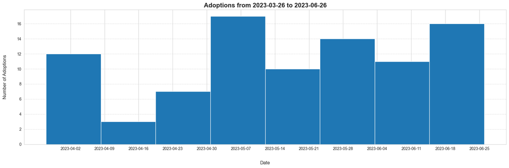

```python
# Calling the 'univariate_histogram' function to plot a histogram of 'Adoptions from 2023-03-26 to 2023-06-26'
univariate_histogram(koa_adoptions_2023, 'Outcome Date', 'Adoptions from 2023-03-26 to 2023-06-26', 'Number of Adoptions')
```

```python
# Checking the statistics of the number of adoptions over the date range
koa_adoptions_2023['Outcome Date'].value_counts().describe().round(2)
```

```
count    39.00
mean      2.31
std       1.42
min       1.00
25%       1.00
50%       2.00
75%       3.00
max       6.00
Name: count, dtype: float64
```

```python
# Total number of adoptions in koa_adoptions_2023
koa_adoptions_2023['Outcome Date'].value_counts().sum()
```

```
90
```

**General Observations**:

- A total of 90 adoptions were recorded over 39 days.
- The average number of adoptions on days when adoptions occurred is approximately 2.31, with some days experiencing as many as 6 adoptions.
- There's a significant number of days, 53 out of 92 days, where no adoptions took place. This suggests periods of low engagement or potential external factors affecting adoption rates.
- The data shows variability in daily adoptions, with some days having a notably higher number of adoptions and many days with none at all.

### Histogram of Donations

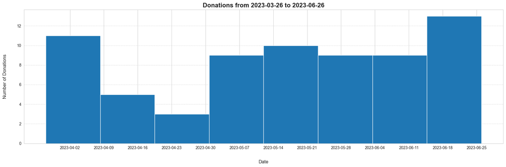

```python
# Calling the 'univariate_histogram' function to plot a histogram of 'Donations from 2023-03-26 to 2023-06-26'
univariate_histogram(donations_2023, 'Transaction Date', 'Donations from 2023-03-26 to 2023-06-26', 'Number of Donations')
```

```python
# Checking the statistics of the number of donations over the date range
donations_2023['Transaction Date'].value_counts().describe().round(2)
```

```
count    38.00
mean      1.82
std       1.16
min       1.00
25%       1.00
50%       1.50
75%       2.00
max       6.00
Name: count, dtype: float64
```

### Count Plot of 'Primary Breed'

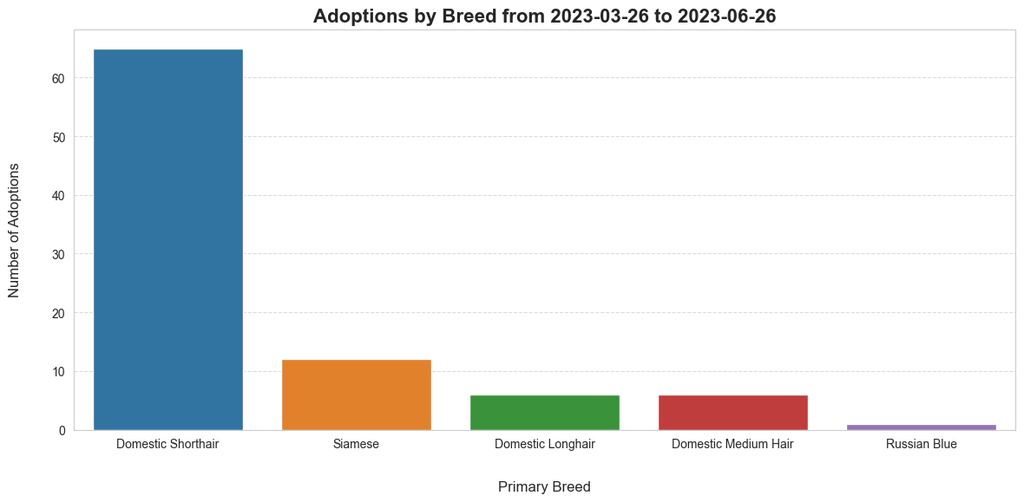

```python
# Using a count plot to plot the 'Primary Breed' from the 'koa_adoptions_2023' dataset to see the distribution of adoptions by breed
plt.figure(figsize=(14, 6))

sns.countplot(data=koa_adoptions_2023, x='Primary Breed', order=koa_adoptions_2023['Primary Breed'].value_counts().index)
plt.title('Adoptions by Breed from 2023-03-26 to 2023-06-26', fontsize=16, fontweight='bold')
plt.xlabel('Primary Breed', labelpad=25, fontsize=12)
plt.ylabel('Number of Adoptions', labelpad=25, fontsize=12)
plt.grid(axis='y', linestyle='--', alpha=0.7)
plt.show()
```

```python
# Describing the statistics of the 'Primary Breed' column
koa_adoptions_2023['Primary Breed'].describe()
```

```
count                     90
unique                     5
top       Domestic Shorthair
freq                      65
Name: Primary Breed, dtype: object
```

**General Observations**:

- The Domestic Shorthair breed is the most adopted, with a frequency of 65 out of the 90 total adoptions. This makes it the dominant breed in this dataset.
- There are 5 unique breeds present in the dataset, indicating a limited variety of breeds being adopted during this period.
- The other breeds have significantly fewer adoptions compared to the Domestic Shorthair. The vast difference suggests that there might be a higher preference or availability for the Domestic Shorthair breed.
- Given the total count of 90 adoptions, and with the Domestic Shorthair accounting for 65 of those, it indicates that more than two-thirds of all adoptions are of this specific breed.

### Defining a Bar Chart Function

```python
def univariate_bar_chart(data, x_col, y_col, title, x_label, y_label):
    """
    Plots a univariate bar chart.

    Parameters:
    data: The dataset to be plotted.
    x_col: The column to be plotted on the x-axis.
    y_col: The column to be plotted on the y-axis.
    title: The title of the plot.
    x_label: The label of the x-axis.
    y_label: The label of the y-axis.
    """

    plt.figure(figsize=(14, 6))

    # Plotting the bar chart
    plt.bar(data=data, x=x_col, height=y_col)

    # Setting title, labels, and other plot aesthetics
    plt.title(title, fontsize=16, fontweight='bold')

    # Calculating the number of weeks between the min and max date for bins
    num_weeks = int((data[x_col].max() - data[x_col].min()).days / 7) + 1
    plt.xticks(pd.date_range(data[x_col].min(), data[x_col].max(), freq='W'))

    plt.xlabel(x_label, labelpad=25, fontsize=12)
    plt.ylabel(y_label, labelpad=25, fontsize=12)
    plt.grid(axis='y', linestyle='--', alpha=0.7)

    plt.tight_layout()
    plt.show()
```

### Bar Chart of 'Clicks' from the Google Ads Adoption Campaign

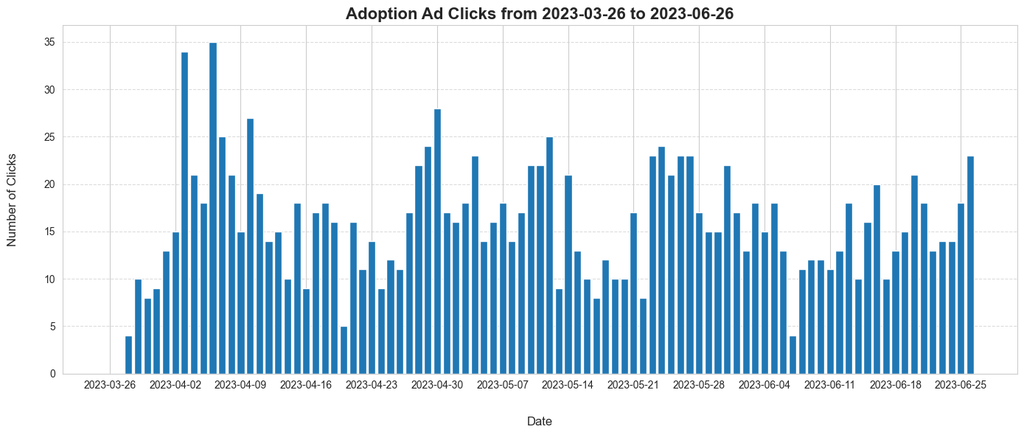

```python
# Calling the 'univariate_bar_chart' function to plot a bar chart of 'Adoption Ad Clicks from 2023-03-26 to 2023-06-26'
univariate_bar_chart(google_ads_adoption, 'Date', 'Clicks', 'Adoption Ad Clicks from 2023-03-26 to 2023-06-26', 'Date', 'Number of Clicks')
```

```python
# Checking the statistics of the number of clicks over the date range
google_ads_adoption['Clicks'].describe().round(2)
```

```
count    93.00
mean     15.73
std       6.29
min       0.00
25%      12.00
50%      15.00
75%      19.00
max      35.00
Name: Clicks, dtype: float64
```

**General Observations**:

- The average number of clicks per day is approximately 15.73, with a standard deviation of about 6.29. This indicates variability in the daily clicks, with some days notably deviating from the average.
- Most days see a number of clicks around the median value of 15. The interquartile range spans from 12 clicks to 19 clicks, showing that the middle 50% of the data has a relatively tight distribution.
- The distribution is right-skewed, with a maximum number of clicks reaching up to 35 on certain days, while the minimum is 0. This suggests that there are a few days with notably higher clicks than the typical day.
- The days with zero clicks might indicate periods where the ads weren't effective or weren't shown at all.

### Bar Chart of 'Clicks' from the Google Ads Donation Campaign

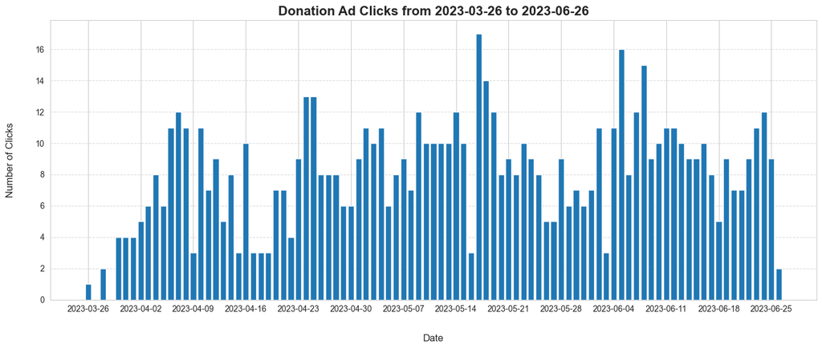

```python
# Calling the 'univariate_bar_chart' function to plot a bar chart of 'Donation Ad Clicks from 2023-03-26 to 2023-06-26'
univariate_bar_chart(google_ads_donation, 'Date', 'Clicks', 'Donation Ad Clicks from 2023-03-26 to 2023-06-26', 'Date', 'Number of Clicks')
```

```python
# Checking the statistics of the number of clicks over the date range
google_ads_donation['Clicks'].describe().round(2)
```

```
count    93.00
mean      8.06
std       3.44
min       0.00
25%       6.00
50%       8.00
75%      10.00
max      17.00
Name: Clicks, dtype: float64
```

**General Observations**:

- On average, there are about 8 clicks per day related to donations, with a standard deviation of roughly 3.44. This indicates that the number of daily clicks for donations has some variability, though not as pronounced as the adoption ads.
- The median number of click stands at 8, suggesting the donation ads get around 8 clicks per day.
- The interquartile range spans from 6 clicks to 10 clicks. This range indicates that the middle 50% of the data is relatively consistent, with days usually seeing between 6 to 10 clicks.
- The distribution seems to be mildly right-skewed, with a few days reaching up to 17 clicks, which is notably higher than the average. On the other hand, the minimum value of 0 clicks suggests there are certain days when the donation ads might not have been effective or perhaps weren't shown.
- It's interesting to note that while the donation ads see fewer clicks on average compared to adoption ads, they still maintain a relatively consistent engagement, which may hint at a dedicated subset of the audience who are keenly interested in donations.

## Bivariate Exploration

### Defining a Function for Box Plots with Swarm Overlay

```python
def box_plot_swarm_overlay(data, x_col, y_col, title, x_label, y_label):
    """
    Plots a box plot and swarm plot overlay.

    Parameters:
    data: The dataset to be plotted.
    x_col: The column to be plotted on the x-axis.
    y_col: The column to be plotted on the y-axis.
    title: The title of the plot.
    x_label: The label of the x-axis.
    y_label: The label of the y-axis.
    """

    plt.figure(figsize=(14, 6))

    # Plotting the box plot and swarm plot overlay
    sns.boxplot(x=data[x_col], y=data[y_col], palette="Blues")
    sns.swarmplot(x=data[x_col], y=data[y_col], color="red", size=3)

    # Setting title, labels, and other plot aesthetics
    plt.title(title, fontsize=16, fontweight='bold')
    plt.xlabel(x_label, labelpad=25, fontsize=12)
    plt.ylabel(y_label, labelpad=25, fontsize=12)
    plt.grid(axis='y', linestyle='--', alpha=0.7)

    plt.tight_layout()
    plt.show()
```

```python
# Defining a function to extract the month from a specified date column and add it as a new 'Month' column to the DataFrame
def extract_month(df, date_col):
    """
    Extract the month from a specified date column and add it as a new 'Month' column to the DataFrame.

    Parameters:
    df: DataFrame containing the date column.
    date_col: Column name containing the date values.
    """

    df['Month'] = pd.to_datetime(df[date_col]).dt.month
```

```python
# Caling the 'extract_month' function
extract_month(donations_2023, 'Transaction Date')
extract_month(google_ads_adoption, 'Date')
extract_month(google_ads_donation, 'Date')
```

### Scatter Plot of 'Transaction Date' vs. 'Donation Amount'

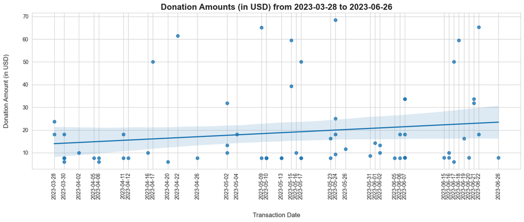

```python
# Plotting a scatter plot of 'Transaction Date' vs 'Donation Amount' from the 'donations_2022' dataset

# Converting 'Transaction Date' to datetime format
donations_2023['Transaction Date'] = pd.to_datetime(donations_2023['Transaction Date'])

# Converting datetime to ordinal numbers for plotting
x_dates = donations_2023['Transaction Date']
x_ord = x_dates.apply(lambda x: x.toordinal())

# Plotting a scatter plot with a regression line
plt.figure(figsize=(14, 6))
sns.regplot(x=x_ord, y=donations_2023['Donation Amount'])

# Setting the x-ticks to be the original dates
plt.xticks(x_ord.unique(), x_dates.dt.strftime('%Y-%m-%d').unique(), rotation=90)

plt.title('Donation Amounts (in USD) from 2023-03-28 to 2023-06-26', fontsize=16, fontweight='bold')
plt.xlabel('Transaction Date', labelpad=25, fontsize=12)
plt.ylabel('Donation Amount (in USD)', labelpad=25, fontsize=12)
plt.tight_layout()
plt.show()
```

**General Observations**:

- The scatter plot displays sporadic distribution of donation amounts across time, indicating unpredictable donations.
- Days with high donations contrast with days of lower donations, hinting at sporadic donor engagement.
- Most donations lie within a specific range, with few higher outliers, suggesting a common donation bracket.
- Periodic clusters of higher donations might indicate seasonal or monthly patterns.

**Relationships Observed**:

- The scatter plot shows variability in donation amounts over time.
- Possible patterns or events lead to donation spikes.
- Occasional donation spikes might be influenced by external factors not shown in the plot.

### Box Plot of 'Donation Amount' (in USD) by Month

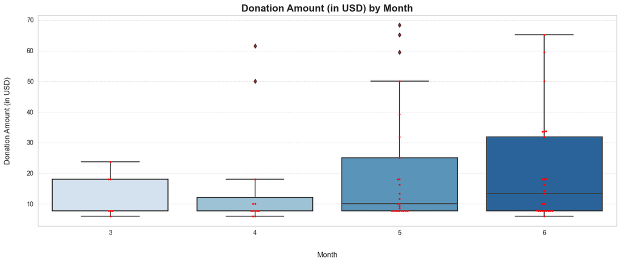

```python
# Calling the 'box_plot_swarm_overlay' function to plot 'Donation Amount (in USD) by Month'
box_plot_swarm_overlay(donations_2023, 'Month', 'Donation Amount', 'Donation Amount (in USD) by Month', 'Month', 'Donation Amount (in USD)')
```

**General Observations**:

- The box plot depicts distribution of donation amounts across different months, with the swarmplot overlay providing individual data point visualization.
- Red dots indicate individual donations, revealing density and spread within each month.
- Some months exhibit wider interquartile ranges, suggesting variability in donation amounts.
- Several months have outliers, representing unusually high or low donations.

**Relationships Observed**:

- The box plot shows variability in median donation amounts across different months.
- The swarm plot reveals days with notably high or low donations in specific months.
- Some months might have events or campaigns leading to higher/lower donations, as indicated by the swarm plot.

### Box Plot of Google Ads Adoption Campaign 'Clicks' by Month

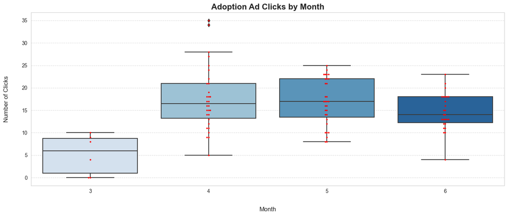

```python
# Calling the 'box_plot_swarm_overlay' function to plot 'Adoption Ad Clicks by Month'
box_plot_swarm_overlay(google_ads_adoption, 'Month', 'Clicks', 'Adoption Ad Clicks by Month', 'Month', 'Number of Clicks')
```

**Relationships Observed**:

- The box plot demonstrates variation in median clicks across months.
- The swarm plot shows specific days with pronounced high or low ad clicks in particular months.
- Once again, some months may have special campaigns or events leading to increased/decreased ad engagement, as demonstrated by the swarmplot.

### Box Plot of Google Ads Donation Campaign 'Clicks' by Month

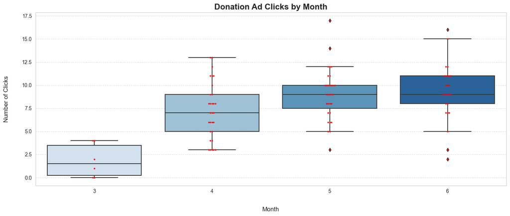

```python
# Calling the 'box_plot_swarm_overlay' function to plot 'Donation Ad Clicks by Month'
box_plot_swarm_overlay(google_ads_donation, 'Month', 'Clicks', 'Donation Ad Clicks by Month', 'Month', 'Number of Clicks')
```

**General Observations**:

- The box plot shows the click distribution across different months for donation ads. The swarmplot overlay reveals individual data points.
- The red dots indicate individual click data, highlighting the density and spread within each month.
- Some months possess broader interquartile ranges, meaning there are fluctuations in clicks for donation ads.
- A few months present outliers, suggesting days with particularly high or low ad clicks.

**Relationships Observed**:

- The box plot showcases variations in median clicks across months for donation ads.
- The swarm plot offers insights into specific days with increased or decreased ad engagement in certain months.
- Distinctive patterns in certain months might be indicative of special campaigns or events influencing ad clicks.

### Violin Plot of 'Clicks' for Adoption vs. Donation Campaigns

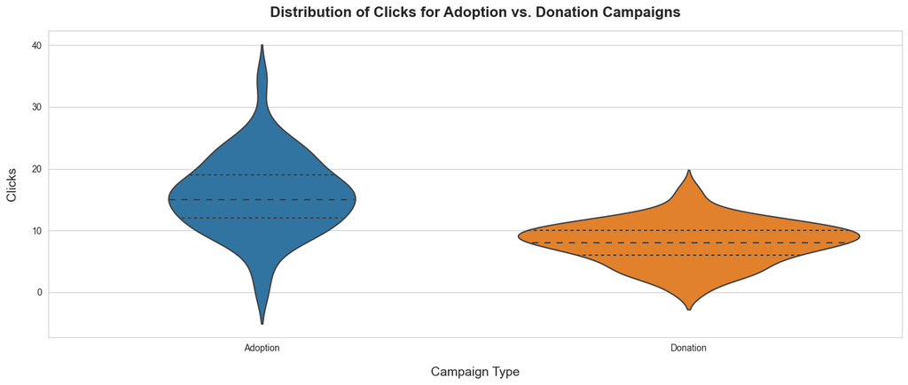

```python
# Plotting a violin plot to visualize the distribution of 'Clicks' for Adoption vs. Donation Campaigns

plt.figure(figsize=(14, 6))
sns.violinplot(data=[google_ads_adoption['Clicks'], google_ads_donation['Clicks']], inner="quartile")
plt.xticks([0, 1], ['Adoption', 'Donation'])
plt.ylabel('Clicks', fontsize=14, labelpad=15)
plt.xlabel('Campaign Type', fontsize=14, labelpad=15)
plt.title('Distribution of Clicks for Adoption vs. Donation Campaigns', fontsize=16, fontweight='bold', pad=15)
plt.tight_layout()
plt.show()
```

**General Observations**:

- The violin plot compares the distribution of clicks between 'Adoption' and 'Donation' campaigns.
- 'Adoption' campaigns seem to have a wider distribution and higher density of clicks compared to 'Donation' campaigns.
- The inner quartile lines show that 'Adoption' campaigns have a higher median and wider interquartile range than 'Donation' campaigns.
- Both campaigns display variability in clicks, but 'Adoption' campaigns tend to have a more varied distribution.

**Relationships Observed**:

- The violin plot effectively contrasts the distributions of clicks between 'Adoption' and 'Donation' campaigns, with 'Adoption' generally having higher engagement.
- The pronounced difference in distributions between the two campaigns might hint at varying marketing strategies, target audiences, or ad placements.

## Multivariate Exploration

```python
donations_2023.head(0)
```

|  | Transaction ID | Transaction Date | Donation Amount | Month |
| --- | --- | --- | --- | --- |

```python
google_ads_donation.head(0)
```

|  | Date | Clicks | Impressions | CTR | Cost | Month |
| --- | --- | --- | --- | --- | --- | --- |

```python
# Merging the dataframes based on dates
donations_ads_merged = pd.merge(google_ads_donation, donations_2023, left_on='Date', right_on='Transaction Date', how='outer')

# Sorting the merged dataframe by date
donations_ads_merged = donations_ads_merged.sort_values(by='Date')
```

```python
donations_ads_merged.head()
```

|  | Date | Clicks | Impressions | CTR | Cost | Month_x | Transaction ID | Transaction Date | Donation Amount | Month_y |
| --- | --- | --- | --- | --- | --- | --- | --- | --- | --- | --- |
| 0 | 2023-03-26 | 1 | 4 | 25.00% | $12.30 | 3 | NaN | NaT | NaN | NaN |
| 1 | 2023-03-27 | 0 | 2 | 0.00% | $0.00 | 3 | NaN | NaT | NaN | NaN |
| 2 | 2023-03-28 | 2 | 14 | 14.29% | $29.97 | 3 | RTLA-T-938 | 2023-03-28 | 18.05 | 3.0 |
| 3 | 2023-03-28 | 2 | 14 | 14.29% | $29.97 | 3 | RTLA-T-937 | 2023-03-28 | 23.69 | 3.0 |
| 4 | 2023-03-29 | 0 | 2 | 0.00% | $0.00 | 3 | NaN | NaT | NaN | NaN |

```python
# Dropping the 'Month_y' column and renmaing the 'Month_x' column to 'Month'
donations_ads_merged.drop(columns=['Month_y'], inplace=True)
donations_ads_merged.rename(columns={'Month_x': 'Month'}, inplace=True)

donations_ads_merged.head()
```

|  | Date | Clicks | Impressions | CTR | Cost | Month | Transaction ID | Transaction Date | Donation Amount |
| --- | --- | --- | --- | --- | --- | --- | --- | --- | --- |
| 0 | 2023-03-26 | 1 | 4 | 25.00% | $12.30 | 3 | NaN | NaT | NaN |
| 1 | 2023-03-27 | 0 | 2 | 0.00% | $0.00 | 3 | NaN | NaT | NaN |
| 2 | 2023-03-28 | 2 | 14 | 14.29% | $29.97 | 3 | RTLA-T-938 | 2023-03-28 | 18.05 |
| 3 | 2023-03-28 | 2 | 14 | 14.29% | $29.97 | 3 | RTLA-T-937 | 2023-03-28 | 23.69 |
| 4 | 2023-03-29 | 0 | 2 | 0.00% | $0.00 | 3 | NaN | NaT | NaN |

```python
# Convert cost to float and remove '$'
donations_ads_merged['Cost'] = donations_ads_merged['Cost'].str.replace('$', '').str.strip().astype(float)
```

```python
# Removing all entries with no cost
donations_ads_merged = donations_ads_merged[donations_ads_merged['Cost'] != 0]
```

### Defining a Scatter Plot Function

```python
def scatter_plot(df, x_col, y_col, size_col, title, xlabel, ylabel):
    """
    Plot a scatter plot with the specified columns and aesthetics.

    Parameters:
    df: DataFrame containing the columns to be plotted.
    x_col: The column to be plotted on the x-axis.
    y_col: The column to be plotted on the y-axis.
    size_col: The column to be plotted as the size of the points.
    title: The title of the plot.
    xlabel: The label of the x-axis.
    ylabel: The label of the y-axis.
    """

    plt.figure(figsize=(14, 6))
    sns.scatterplot(data=df, x=x_col, y=y_col, size=size_col, sizes=(30, 250), alpha=0.6)
    plt.title(title, fontsize=16, fontweight='bold', pad=15)
    plt.xlabel(xlabel, labelpad=25, fontsize=12)
    plt.ylabel(ylabel, labelpad=25, fontsize=12)

    plt.legend(title=size_col, loc='upper left', fontsize=12, title_fontsize=12)
    plt.tight_layout()
    plt.show()
```

### Scatter Plot of 'Clicks' vs. 'Date' from 'donations_ads_merged', Sized by 'Cost'

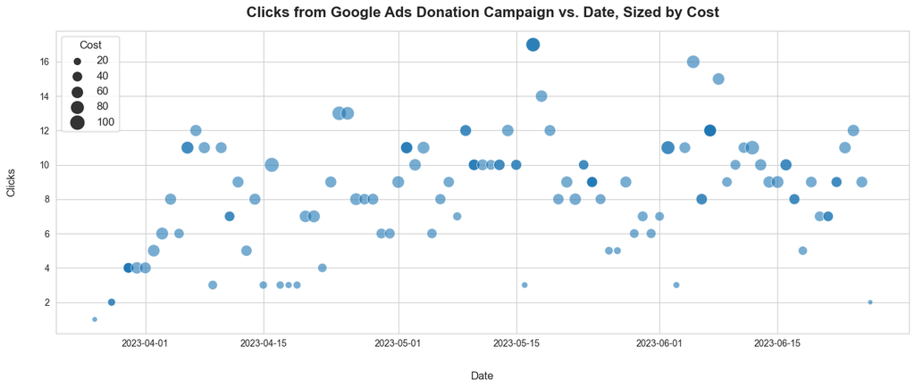

```python
# Calling the 'scatter_plot' function to plot 'Clicks from donations_ads_merged vs. Date, Sized by Cost'
scatter_plot(donations_ads_merged, 'Date', 'Clicks', 'Cost', 'Clicks from Google Ads Donation Campaign vs. Date, Sized by Cost', 'Date', 'Clicks')
```

**General Observations**:

- The scatter plot depicts 'Clicks' against 'Date' for the Google Ads Donation Campaign, where the size of each point represents the 'Cost' associated with that day.
- The clicks seem to fluctuate without a consistent trend. This suggests that the number of clicks is not necessarily increasing or decreasing steadily over time.
- There's a wide range of costs associated with each day's clicks, as indicated by the varying sizes of the dots. Bigger dots don't necessarily correspond to higher clicks, which might suggest that some days had a higher cost per click.
- The density of larger dots appears to be spread out throughout the time frame, meaning high-cost days are distributed sporadically and not clustered in a specific period.
- Some days with larger dots do not have a correspondingly high number of clicks. This might imply that certain days, despite the higher advertising spend, did not necessarily yield a higher engagement.

**Relationships Observed**:

- There doesn't appear to be a clear positive correlation between the size of the dots (Cost) and the number of clicks. This implies that spending more doesn't necessarily guarantee more clicks on a given day.
- The variability in the number of clicks, despite the associated costs, suggests that factors other than advertising spend might be influencing user engagement. This could be related to the content of the ads, the platforms they were shown on, or external events affecting user behavior.
- The spread of the data across clicks indicates that while there are days with high engagement, there are also days with notably low engagement, regardless of the associated advertising cost.

```python
# Merging 'koa_adoptions_2023' and 'google_ads_adoption' dataframes based on dates
adoptions_ads_merged = pd.merge(google_ads_adoption, koa_adoptions_2023, left_on='Date', right_on='Outcome Date', how='outer')

# Sorting the merged dataframe by date
adoptions_ads_merged = adoptions_ads_merged.sort_values(by='Date')

adoptions_ads_merged.head()
```

|  | Date | Clicks | Impressions | CTR | Cost | Month | Outcome Date | Animal ID | Name | Species | Primary Breed | Sex | Outcome Description |
| --- | --- | --- | --- | --- | --- | --- | --- | --- | --- | --- | --- | --- | --- |
| 0 | 2023-03-26 | 0 | 1 | 0.00% | $0.00 | 3 | NaT | NaN | NaN | NaN | NaN | NaN | NaN |
| 1 | 2023-03-27 | 0 | 0 | 0.00% | $0.00 | 3 | NaT | NaN | NaN | NaN | NaN | NaN | NaN |
| 2 | 2023-03-28 | 4 | 44 | 9.09% | $58.20 | 3 | 2023-03-28 | RTLA-A-1105 | Rosemary | Cat | Domestic Shorthair | Female | Adoption - Mobile Adoption |
| 3 | 2023-03-28 | 4 | 44 | 9.09% | $58.20 | 3 | 2023-03-28 | RTLA-A-1098 | Petri | Cat | Domestic Shorthair | Male | Adoption - Mobile Adoption |
| 4 | 2023-03-28 | 4 | 44 | 9.09% | $58.20 | 3 | 2023-03-28 | RTLA-A-1097 | Pipette | Cat | Siamese | Female | Adoption - Mobile Adoption |

```python
# Convert cost to float and remove '$'
adoptions_ads_merged['Cost'] = adoptions_ads_merged['Cost'].str.replace('$', '').str.strip().astype(float)
```

```python
# Removing all entries with no cost
adoptions_ads_merged = adoptions_ads_merged[adoptions_ads_merged['Cost'] != 0]
```

### Scatter Plot of 'Clicks' vs. 'Outcome Date' from 'adoptions_ads_merged', Sized by 'Cost'

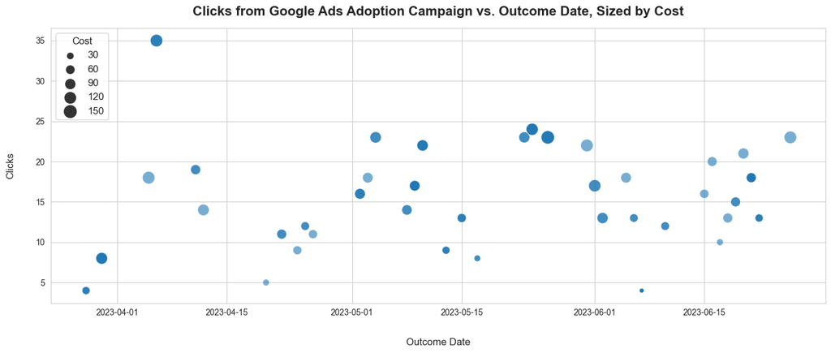

```python
# Calling the 'scatter_plot' function to plot 'Clicks vs. Outcome Date from adoptions_ads_merged, Sized by Cost'
scatter_plot(adoptions_ads_merged, 'Outcome Date', 'Clicks', 'Cost', 'Clicks from Google Ads Adoption Campaign vs. Outcome Date, Sized by Cost', 'Outcome Date', 'Clicks')
```

**General Observations**:

- The scatterplot showcases 'Clicks' against 'Outcome Date' for the Google Ads Adoption Campaign, with the 'Cost' for each day influencing the size of the points.
- Clicks vary over the date range, indicating inconsistent daily engagement.
- The varying sizes of the dots demonstrate that the advertising costs differ day by day. Larger dots don't always align with days having more clicks, suggesting that higher costs don't guarantee increased engagement.
- Days with considerable advertising costs are dispersed throughout the timeline, not being confined to a specific period.
- There are instances where days with a higher advertising cost did not result in a proportionate increase in clicks.

**Relationships Observed**:

- The size of the dots and the number of clicks don't appear to have a direct positive correlation, suggesting other influencing factors beyond just advertising spend.
- The range in the number of clicks, regardless of the cost, hints at external elements or ad strategies affecting engagement.
- The distribution of data indicates days of both high and low engagement, irrespective of the advertising cost, pointing towards the need for a deeper analysis of ad content, placement, or timing.

### Facet Plot of 'Clicks' vs. 'Donation Amount' Faceted by 'Month', from 'donations_ads_merged'

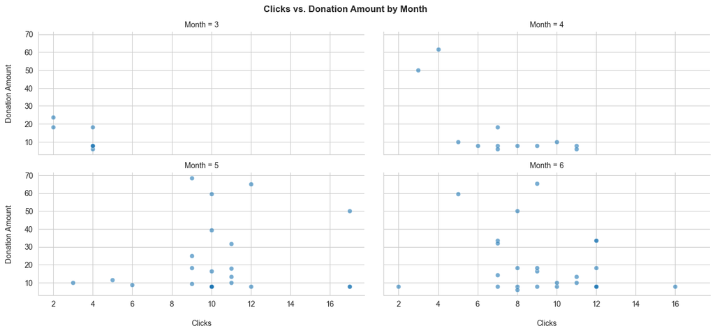

```python
# Plotting a facet plot of 'Clicks' vs. 'Donation Amount' faceted by 'Month', using the 'donations_ads_merged' dataset
facet = sns.FacetGrid(data=donations_ads_merged, col='Month', col_wrap=2, height=3)
facet.map(sns.scatterplot, 'Clicks', 'Donation Amount', alpha=0.6)
facet.set_axis_labels('Clicks', 'Donation Amount', labelpad=15)
facet.fig.set_size_inches(14, 6)
facet.fig.subplots_adjust(top=0.9)
facet.fig.suptitle('Clicks vs. Donation Amount by Month', fontsize=12, fontweight='bold')
plt.show()
```

```python
# Calculating the number of adoptions in 'adoptions_ads_merged' by totalling the number of 'Outcome Date' entries
adoptions_ads_merged['Outcome Date'].value_counts().sum()

# Creating a new column for adoptions based on if there is an 'Outcome Date' entry.
adoptions_ads_merged['Adoption'] = np.where(adoptions_ads_merged['Outcome Date'].isnull(), 0, 1)

# Confirming the change
adoptions_ads_merged.head()
```

|  | Date | Clicks | Impressions | CTR | Cost | Month | Outcome Date | Animal ID | Name | Species | Primary Breed | Sex | Outcome Description | Adoption |
| --- | --- | --- | --- | --- | --- | --- | --- | --- | --- | --- | --- | --- | --- | --- |
| 2 | 2023-03-28 | 4 | 44 | 9.09% | 58.20 | 3 | 2023-03-28 | RTLA-A-1105 | Rosemary | Cat | Domestic Shorthair | Female | Adoption - Mobile Adoption | 1 |
| 3 | 2023-03-28 | 4 | 44 | 9.09% | 58.20 | 3 | 2023-03-28 | RTLA-A-1098 | Petri | Cat | Domestic Shorthair | Male | Adoption - Mobile Adoption | 1 |
| 4 | 2023-03-28 | 4 | 44 | 9.09% | 58.20 | 3 | 2023-03-28 | RTLA-A-1097 | Pipette | Cat | Siamese | Female | Adoption - Mobile Adoption | 1 |
| 5 | 2023-03-29 | 10 | 105 | 9.52% | 169.09 | 3 | NaT | NaN | NaN | NaN | NaN | NaN | NaN | 0 |
| 10 | 2023-03-30 | 8 | 144 | 5.56% | 134.98 | 3 | 2023-03-30 | RTLA-A-1103 | Bueller | Cat | Russian Blue | Male | Adoption - Mobile Adoption | 1 |

### Facet Plot of 'Clicks' vs. 'Cost' Faceted by 'Primary Breed', from 'adoptions_ads_merged'

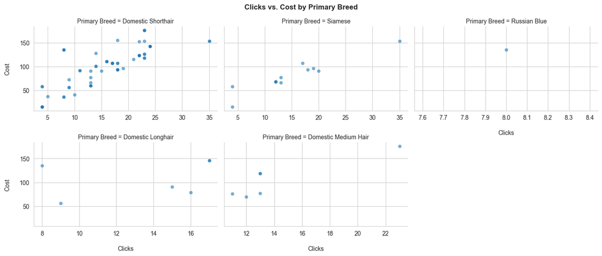

```python
# Plotting a facet plot of 'Clicks' vs. 'Cost' faceted by 'Primary Breed', using the 'adoptions_ads_merged' dataset
facet = sns.FacetGrid(data=adoptions_ads_merged, col='Primary Breed', col_wrap=3, height=3, sharex=False)
facet.map(sns.scatterplot, 'Clicks', 'Cost', alpha=0.6)
facet.set_axis_labels('Clicks', 'Cost', labelpad=15)
facet.fig.set_size_inches(14, 6)
facet.fig.subplots_adjust(hspace=.5)
facet.fig.subplots_adjust(top=0.9)
facet.fig.suptitle('Clicks vs. Cost by Primary Breed', fontsize=12, fontweight='bold')
plt.tight_layout()
plt.show()
```

**General Observations**:

- The facet plot segregates the relationship between 'Clicks' and 'Cost' based on the 'Primary Breed'.
- Each facet represents a different primary breed, and the data points within each facet illustrate the relationship between the advertising cost and the number of clicks garnered.
- While some breeds, like the 'Domestic Shorthair', display a dense concentration of data points, others have a more sparse representation, indicating variability in the ad campaign's reach and effectiveness across breeds.
- The range of clicks and cost seems to be inconsistent across the breeds, suggesting that the campaign's effectiveness differs depending on the breed being promoted.
- There are instances in several breeds where higher costs did not result in a proportionally higher number of clicks.

**Relationships Observed**:

- For breeds like the Domestic Shorthair and 'Domestic Medium Hair', there's a notable spread in the data points, suggesting variability in both advertising costs and engagement on different days.
- Breeds like 'Domestic Long Hair' show less variability, implying that advertising costs and engagement might be more consistent for these breeds.
- The lack of a consistent positive correlation between cost and clicks across breeds suggests that factors other than advertising spend could be influencing engagement. This could include the popularity of certain breeds, the content of the ads, or the Gooogle Ads platform.
- Given the variability across breeds, it might be beneficial to tailor advertising strategies to any specific breed being promoted.

### Combined Histogram for 'Clicks' Distribution

```python
# Loading ads_merged.csv
ads_merged = pd.read_csv('ads_merged.csv')
```

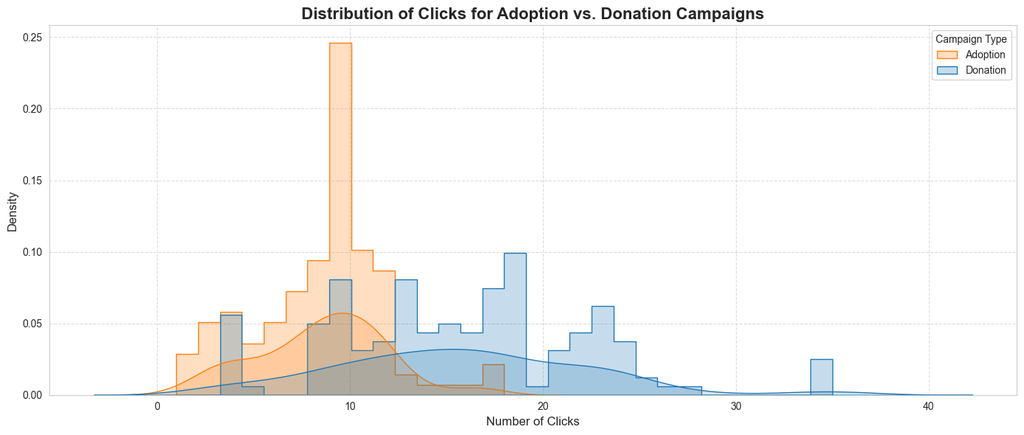

```python
# Plotting a histogram with a density line overlay
plt.figure(figsize=(14,6))
sns.histplot(ads_merged, x='Clicks', hue='Campaign Type', element='step', stat='density', common_norm=False, bins=30)

# Applying a KDE line overlay
sns.kdeplot(data=ads_merged, x='Clicks', hue='Campaign Type', fill=True, alpha=0.2)

plt.title('Distribution of Clicks for Adoption vs. Donation Campaigns', fontsize=16, fontweight='bold')
plt.xlabel('Number of Clicks', fontsize=12)
plt.ylabel('Density', fontsize=12)
plt.legend(title='Campaign Type', loc='upper right', labels=['Adoption', 'Donation'])
plt.grid(axis='both', linestyle='--', alpha=0.7)
plt.tight_layout()
plt.show()
```

**General Observations**:

### Box Plots for 'Cost' Distribution by 'Campaign Type'

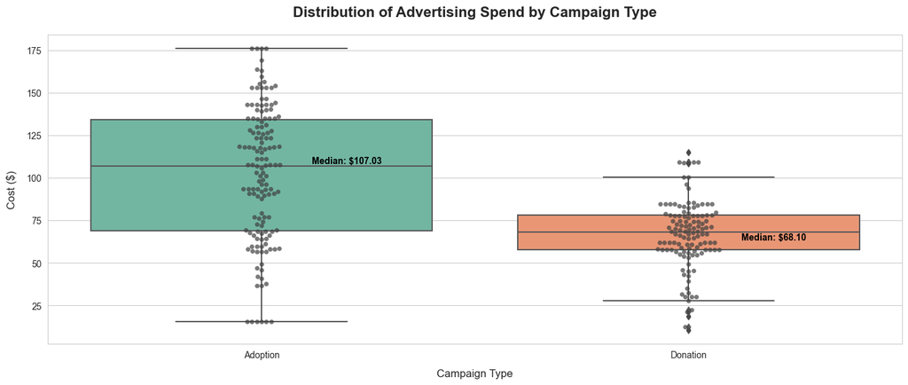

```python
plt.figure(figsize=(14,6))

# Setting the background style
sns.set_style("whitegrid")

# Plotting the Boxplot
sns.boxplot(data=ads_merged, x='Campaign Type', y='Cost', palette="Set2",)

# Overlaying swarmplot with jitter and adjusted alpha
sns.swarmplot(data=ads_merged, x='Campaign Type', y='Cost', color=".25", alpha=0.7, size=5)

# Annotating with median values
median_values = {'Adoption': 107.03, 'Donation': 68.10} # Rounded to 2 decimal places
for i, (campaign_type, median) in enumerate(median_values.items()):
    x_position = i + 0.2
    y_offset = 3 if campaign_type == 'Adoption' else -3
    plt.text(x_position, median + y_offset, f"Median: ${median:.2f}", horizontalalignment='center', verticalalignment='center', fontweight='bold', color='black')

plt.title('Distribution of Advertising Spend by Campaign Type', fontsize=16, fontweight='bold', pad=20)
plt.xlabel('Campaign Type', fontsize=12, labelpad=10)
plt.ylabel('Cost ($)', fontsize=12, labelpad=10)
plt.tight_layout()
plt.show()
```

### Facet Plots of 'Clicks' vs. 'Cost' by 'Primary Breed'

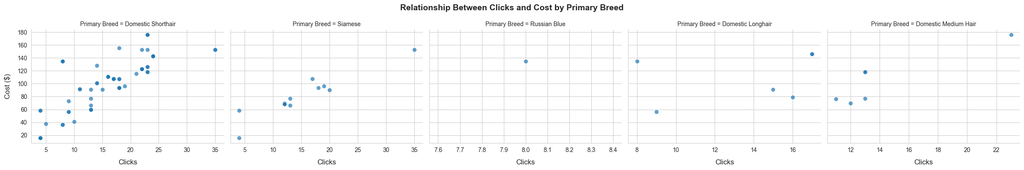

```python
# Plotting the facet plots
facet = sns.FacetGrid(data=adoptions_ads_merged, col='Primary Breed', height=4, aspect=1.2, sharex=False)
facet.map(sns.scatterplot, 'Clicks', 'Cost', alpha=0.7, edgecolor="w", linewidth=0.5, s=50)
facet.set_axis_labels('Clicks', 'Cost ($)', fontsize=12, labelpad=10)
facet.fig.subplots_adjust(hspace=.5, wspace=.2, top=0.85)
facet.fig.suptitle('Relationship Between Clicks and Cost by Primary Breed', fontsize=14, fontweight='bold')
plt.tight_layout()
plt.show()
```

**General Observations**:

- The facet plots explore breed-specific engagement vs. cost patterns.
- Domestic Shorthairs attract attention, while other breeds show varied patterns.
- The visualization offers insights for breed-specific marketing strategies.

```python
# Creating a new column, 'Campaign Type' in 'adoptions_ads_merged' and 'donations_ads_merged' dataframes
adoptions_ads_merged['Campaign Type'] = 'Adoption'
donations_ads_merged['Campaign Type'] = 'Donation'

# Merging the 'adoptions_ads_merged' and 'donations_ads_merged' dataframes
ads_merged = pd.concat([adoptions_ads_merged, donations_ads_merged])
```

```python
# Saving all the cleaned datasets to new csv files for 'Part II'
google_ads_adoption.to_csv('google_ads_adoption_cleaned.csv', index=False)
google_ads_donation.to_csv('google_ads_donation_cleaned.csv', index=False)
donations_ads_merged.to_csv('donations_ads_merged_cleaned.csv', index=False)
adoptions_ads_merged.to_csv('adoptions_ads_merged_cleaned.csv', index=False)
koa_adoptions_2023.to_csv('koa_adoptions_2023_cleaned.csv', index=False)
donations_2023.to_csv('donations_2023_cleaned.csv', index=False)
ads_merged.to_csv('ads_merged.csv', index=False)
```

## Conclusions

### **Summary of Main Findings**:

### 1. **Campaign Engagement**:

- The **Google Ads campaigns** for both adoptions and donations showed variability in terms of engagement.
- **Clicks fluctuated** over time, with some days seeing notably higher or lower engagement compared to others.
- Notably, the **adoption campaign** had a wider distribution and higher density of clicks compared to the donation campaign, suggesting a **stronger overall engagement** for adoption-related ads.

### 2. **Effect of Advertising Spend**:

- A direct correlation between the **advertising spend (Cost)** and the number of clicks was not consistently observed.
- This suggests that **higher spending did not always guarantee more clicks** or engagement.
- This pattern was evident across both the adoption and donation campaigns.

### 4. **Interactions between Features**:

- The size encoding of the scatter plots (representing Cost) revealed that on some days, despite higher advertising spends, the campaigns did not necessarily yield more engagement.
- The **facet plots** further emphasized the breed-specific variability in the relationship between advertising costs and engagement.

## **Reflection on the Data Exploration Process**:

### 1. **Univariate Exploration**:

- Initial exploration focused on understanding the distribution of individual variables. **Histograms, box plots, and violin plots** provided insights into the central tendencies and spread of data like clicks and donation amounts.

### 2. **Bivariate Exploration**:

- As I moved to bivariate exploration, relationships between two variables were analyzed. **Scatter plots**, for instance, helped visualize the relationship between clicks and dates, highlighting the variability in engagement over time.

### 3. **Multivariate Exploration**:

- The multivariate analysis brought in an added layer of complexity. By introducing a third variable, such as Cost, using size encoding in scatter plots, I observed **deeper interactions**.
- The use of facet plots allowed for a segmented analysis based on categories like 'Primary Breed', providing **breed-specific insights**.

### 4. **Data Wrangling and Cleaning**:

- During the exploration, the need for data cleaning and merging became evident. Efforts were made to merge relevant datasets based on common attributes, enabling a more comprehensive analysis.
- **Handling missing values**, adjusting data types, and dealing with outliers were crucial steps to ensure the integrity and reliability of the findings.

### 5. **Visualization Challenges and Adjustments**:

- Throughout the exploration, various visualization challenges arose, from overlapping labels to inconsistent axis scales. Iterative adjustments and refinements were made to ensure clarity and accuracy in data representation.

### 6. **Conclusion**:

- The data exploration journey was both informative and enlightening. It emphasized the importance of a systematic approach, starting from univariate analysis and building up to multivariate interactions.
- The findings underscored the value of data-driven decision-making. Understanding how advertising spend translates to engagement, and how this relationship varies by factors like breed, can inform future campaign strategies and resource allocation.